# econ325lab4

1. For the Burrard Street cycling data.
1. Construct a 95% confidence interval for the number of bike trips per month.

Import, view and explore a scatter graph of the data

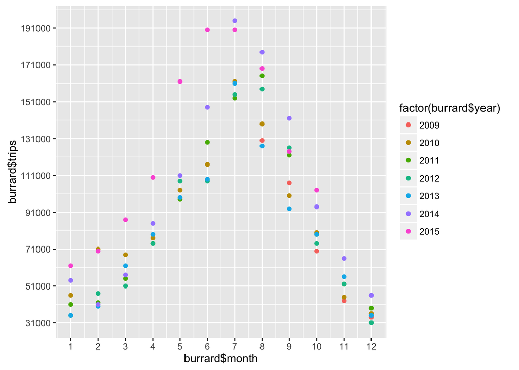

```r
burrard <- read.csv("~/Downloads/burrard.csv")
View(burrard)

library(ggplot2)
burrard.scatter <- ggplot(data = burrard, aes(x = burrard$month, y =
                                                burrard$trips)) +
  geom_point(aes(colour = factor(burrard$year))) + scale_x_continuous(breaks
                                                                      = round(seq(min(burrard$month), max(burrard$month), by = 1),1)) +
  scale_y_continuous(breaks = round(seq(min(burrard$trips),
                                        max(burrard$trips), by = 20000),1))
burrard.scatter
```

Finding confidence intervals two ways: t.test and a longer computation

```r
t.test(burrard$trips)
```

```
##
##  One Sample t-test
##
## data:  burrard$trips
## t = 17.64, df = 74, p-value < 2.2e-16
## alternative hypothesis: true mean is not equal to 0
## 95 percent confidence interval:
##   82258.51 103208.15
## sample estimates:
## mean of x
##  92733.33
```

Alternatively,

```r
qt(.975, 74)
```

```
## [1] 1.992543
```

```r
me <- qt(.975, 74)*sd(burrard$trips)/sqrt(75)
lower.ci <- mean(burrard$trips) - me
lower.ci
```

```
## [1] 82258.51
```

```r
upper.ci <- mean(burrard$trips) + me
upper.ci
```

```
## [1] 103208.2
```

2. Explore the possibility that monthly trips depend on the time of year. Distinguish between months that might be considered warmer and drier (late spring, summer, early fall) and months that might be considered colder and wetter (late fall, winter, early spring). Construct 92% confidence intervals for both times of the year. Is there any overlap of the confidence intervals? Determine the highest level/coefficient of confidence that does not lead to overlap.

Create two dataframes: warm months and cold months

```r
warm <- subset(burrard, month > 3 & month < 10)
cold <- subset(burrard, month > 9 | month < 4)
```

Obtain 92% confidence intervals

```r
t.test(warm$trips, conf.level = 0.92)
```

```
##
##  One Sample t-test
##
## data:  warm$trips
## t = 23.06, df = 37, p-value < 2.2e-16
## alternative hypothesis: true mean is not equal to 0
## 92 percent confidence interval:
##  118323.6 138360.7
## sample estimates:
## mean of x
##  128342.1
```

```r
t.test(cold$trips, conf.level = 0.92)
```

```
##
##  One Sample t-test
##
## data:  cold$trips
## t = 18.587, df = 36, p-value < 2.2e-16
## alternative hypothesis: true mean is not equal to 0
## 92 percent confidence interval:
##  50718.71 61605.61
## sample estimates:
## mean of x
##  56162.16
```

99.99% confidence intervals below show that the CI’s of warm months and cold months will not overlap

```r
t.test(warm$trips, conf.level = 0.9999)
```

```
##
##  One Sample t-test
##
## data:  warm$trips
## t = 23.06, df = 37, p-value < 2.2e-16
## alternative hypothesis: true mean is not equal to 0
## 99.99 percent confidence interval:
##  104081.4 152602.8
## sample estimates:
## mean of x
##  128342.1
```

```r
t.test(cold$trips, conf.level = 0.9999)
```

```
##
##  One Sample t-test
##
## data:  cold$trips
## t = 18.587, df = 36, p-value < 2.2e-16
## alternative hypothesis: true mean is not equal to 0
## 99.99 percent confidence interval:
##  42947.29 69377.04
## sample estimates:
## mean of x
##  56162.16
```

2. For the Nigerian pipeline data
1. Look at a box-plot of the variable related to volume of oil. Are there any outliers in this data? In which way is the data skewed? Remove any outliers from your data set.

Import and view dataset, and analyze boxplot and summary statistics

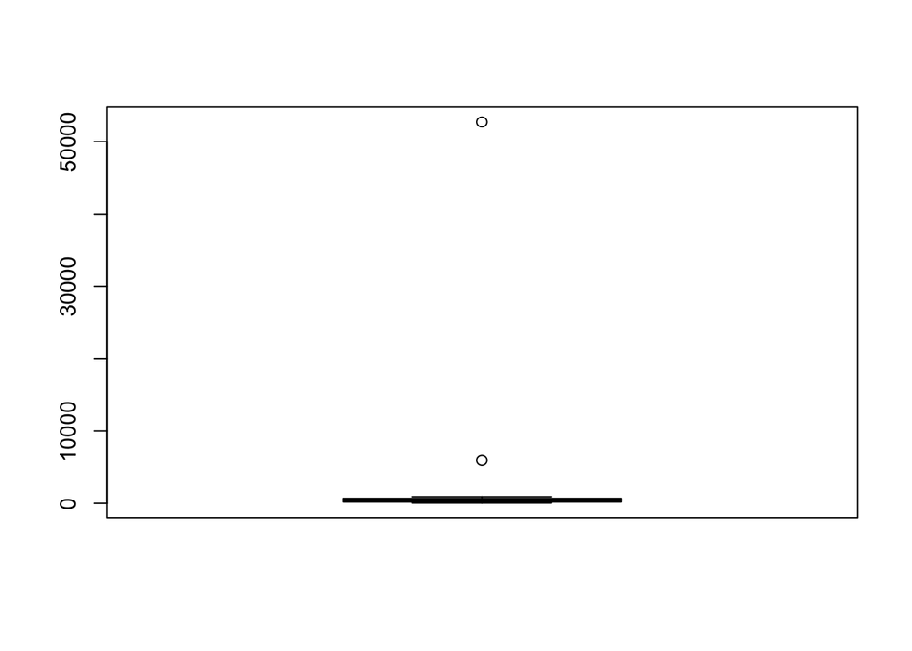

```r
naoc <- read.csv("~/Downloads/naoc.csv")
View(naoc)

boxplot(naoc$barrels)
```

```r
summary(naoc)
```

```
##       obs            month             year          count
##  Min.   : 1.00   Min.   : 1.000   Min.   :2014   Min.   : 8.00
##  1st Qu.: 6.25   1st Qu.: 3.250   1st Qu.:2014   1st Qu.:15.25
##  Median :11.50   Median : 6.000   Median :2014   Median :20.00
##  Mean   :11.50   Mean   : 6.045   Mean   :2014   Mean   :22.41
##  3rd Qu.:16.75   3rd Qu.: 8.750   3rd Qu.:2015   3rd Qu.:27.00
##  Max.   :22.00   Max.   :12.000   Max.   :2015   Max.   :42.00
##     barrels
##  Min.   :   43.58
##  1st Qu.:  196.12
##  Median :  373.89
##  Mean   : 3014.78
##  3rd Qu.:  633.26
##  Max.   :52721.50
```

Remove outliers and compare boxplot and summary statistics to previous

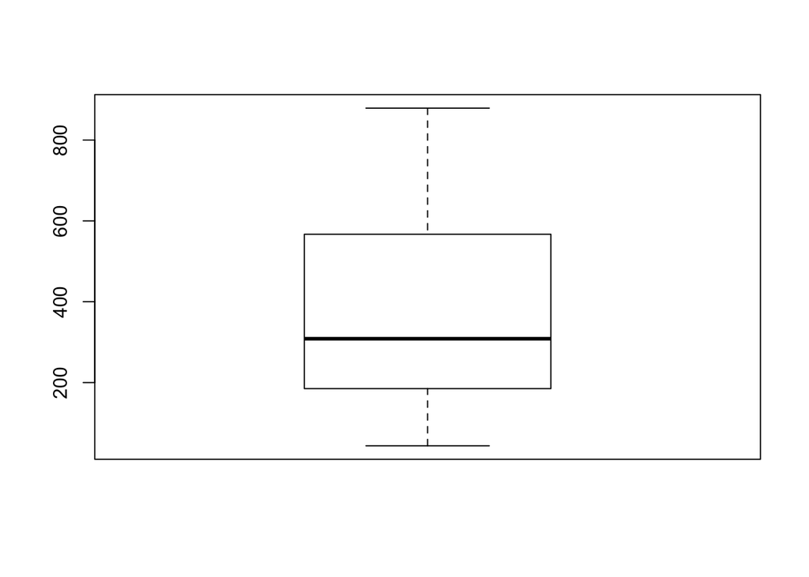

```r
naoc.ed <- subset(naoc, naoc$barrels < 3000)
boxplot(naoc.ed$barrels)
```

```r
summary(naoc.ed)
```

```
##       obs            month            year          count
##  Min.   : 1.00   Min.   : 1.00   Min.   :2014   Min.   : 8.00
##  1st Qu.: 6.75   1st Qu.: 3.75   1st Qu.:2014   1st Qu.:14.75
##  Median :11.50   Median : 6.00   Median :2014   Median :20.00
##  Mean   :11.55   Mean   : 6.15   Mean   :2014   Mean   :21.65
##  3rd Qu.:16.25   3rd Qu.: 9.00   3rd Qu.:2015   3rd Qu.:27.00
##  Max.   :22.00   Max.   :12.00   Max.   :2015   Max.   :42.00
##     barrels
##  Min.   : 43.58
##  1st Qu.:187.52
##  Median :308.48
##  Mean   :382.47
##  3rd Qu.:562.45
##  Max.   :879.01
```

2. Construct a 90% confidence int. for the number of incidents in a month.

```r
t.test(naoc.ed$count, conf.level = 0.90)
```

```
##
##  One Sample t-test
##
## data:  naoc.ed$count
## t = 10.307, df = 19, p-value = 3.225e-09
## alternative hypothesis: true mean is not equal to 0
## 90 percent confidence interval:
##  18.01801 25.28199
## sample estimates:
## mean of x
##     21.65
```

3. Test if the mean amount of oil spilled/lost in a month is less than or equal to 300 barrels. Carry out the test at the = .05 level of significance and also express the p-value for the test.

```r
t.test(naoc.ed$barrels, alternative = "greater", mu = 300, conf.level = 0.95)
```

```
##
##  One Sample t-test
##
## data:  naoc.ed$barrels
## t = 1.5711, df = 19, p-value = 0.06633
## alternative hypothesis: true mean is greater than 300
## 95 percent confidence interval:
##  291.7062      Inf
## sample estimates:
## mean of x
##  382.4725
```

```r
sd(naoc.ed$barrels)
```

```
## [1] 234.7531
```

```r
tcalc <- (382.4725-300)/(234.7531/sqrt(22))
tcalc
```

```
## [1] 1.647818
```

3. For the Ontario Wind data
1. Construct a 96% confidence interval for the variable totalmwh:

```r
ontwind <- read.csv("~/Downloads/ontwind.csv")
View(ontwind)

t.test(ontwind$totalmwh, conf.level = .96)
```

```
##
##  One Sample t-test
##
## data:  ontwind$totalmwh
## t = 122.35, df = 8759, p-value < 2.2e-16
## alternative hypothesis: true mean is not equal to 0
## 96 percent confidence interval:
##  760.9155 786.9014
## sample estimates:
## mean of x
##  773.9084
```

2. Construct a 96% confidence interval for over-night power production (midnight to 5 am).

Create dataframe, “overnight” and perform t-test

```r
overnight <- subset(ontwind, hour > 23 | hour < 6)
View(overnight)

t.test(overnight$totalmwh, conf.level = .96)
```

```
##
##  One Sample t-test
##
## data:  overnight$totalmwh
## t = 65.574, df = 2189, p-value < 2.2e-16
## alternative hypothesis: true mean is not equal to 0
## 96 percent confidence interval:
##  735.6200 783.2175
## sample estimates:
## mean of x
##  759.4187
```

3. Construct 96% confidence intervals for power production by hour. (Use a loop command).

```r
for(i in 1:24){
  hr <- subset(ontwind, hour == i)
  print(t.test(hr$totalmwh, conf.level = .96))
  }
```

```
##
##  One Sample t-test
##
## data:  hr$totalmwh
## t = 27.195, df = 364, p-value < 2.2e-16
## alternative hypothesis: true mean is not equal to 0
## 96 percent confidence interval:
##  720.6379 838.8306
## sample estimates:
## mean of x
##  779.7342
##
##
##  One Sample t-test
##
## data:  hr$totalmwh
## t = 26.99, df = 364, p-value < 2.2e-16
## alternative hypothesis: true mean is not equal to 0
## 96 percent confidence interval:
##  701.3278 817.3024
## sample estimates:
## mean of x
##  759.3151
##
##
##  One Sample t-test
##
## data:  hr$totalmwh
## t = 26.39, df = 364, p-value < 2.2e-16
## alternative hypothesis: true mean is not equal to 0
## 96 percent confidence interval:
##  686.1062 802.3595
## sample estimates:
## mean of x
##  744.2329
##
##
##  One Sample t-test
##
## data:  hr$totalmwh
```

[output cut: 232 more lines]

```
## sample estimates:
## mean of x
##  816.1753
##
##
##  One Sample t-test
##
## data:  hr$totalmwh
## t = 27.24, df = 364, p-value < 2.2e-16
## alternative hypothesis: true mean is not equal to 0
## 96 percent confidence interval:
##  742.1879 863.6970
## sample estimates:
## mean of x
##  802.9425
```

4. Let µi be the mean power generation in hour i (i = 1, …24). Test the following: H0 : µi = µ ∀i

Be sure to specify the appropriate alternate hypothesis. (This is a one-way ANOVA).

Alternate hypothesis: H1 : ∃ i,j: µi ≠ µj (population means are not all equal)

Explore differences in sample means, variances, lengths

```r
tapply(ontwind$totalmwh, ontwind$hour, mean)
```

```
##        1        2        3        4        5        6        7        8
## 779.7342 759.3151 744.2329 733.7151 736.5726 742.0658 729.0904 721.5534
##        9       10       11       12       13       14       15       16
## 703.6466 721.1425 740.0740 762.8822 782.5589 797.3918 806.7014 811.5068
##       17       18       19       20       21       22       23       24
## 811.0438 801.6110 801.4411 814.2137 827.5562 826.6356 816.1753 802.9425
```

```r
tapply(ontwind$totalmwh, ontwind$hour, var)
```

```
##        1        2        3        4        5        6        7        8
## 300055.5 288898.9 290289.2 280834.4 285441.4 311442.6 322406.2 352754.7
##        9       10       11       12       13       14       15       16
## 361178.2 388581.9 401338.3 409951.1 393612.0 378550.2 364811.6 364628.3
##       17       18       19       20       21       22       23       24
## 369927.0 383541.6 384873.9 388347.4 371791.0 355434.8 333603.6 317130.0
```

```r
tapply(ontwind$totalmwh, ontwind$hour, length)
```

```
##   1   2   3   4   5   6   7   8   9  10  11  12  13  14  15  16  17  18
## 365 365 365 365 365 365 365 365 365 365 365 365 365 365 365 365 365 365
##  19  20  21  22  23  24
## 365 365 365 365 365 365
```

One way test assuming equal variances

```r
oneway.test(totalmwh ~ hour, data = ontwind, var.equal = TRUE)
```

```
##
##  One-way analysis of means
##
## data:  totalmwh and hour
## F = 1.5789, num df = 23, denom df = 8736, p-value = 0.03859
```

```r
oneway.test(ontwind$totalmwh ~ ontwind$hour, var.equal = FALSE)
```

```
##
##  One-way analysis of means (not assuming equal variances)
##
## data:  ontwind$totalmwh and ontwind$hour
## F = 1.5723, num df = 23.0, denom df = 3165.1, p-value = 0.04051
```

We reject H0 in both cases.